# LDA CFA and AR(1)

Renee Soler

```r
library(R2jags)
library(here)
```

# Analysis 1: Confirmatory Factor Analysis

## Data Preparation

data in tutorial is in 3 dimensions and ours is in long format so im reshaping so its easier to use down the line.

I also reverse two items because theyre reversed from our construct of the cultural conservative shift

We also mean center the answers because the tutorial used them this way, also we go low ESS on the first try and some sources said that mean centering should help (it did)

```r
# Read in the data from the file
table <- read.csv(here("yllanon.csv"))

data <- table

id_var  <- "id"
time_var <- "wave"
item_vars <- c("abort","adopt","imm")

# removing "dont know" and "I haven’t thought much about it" responses

data$abort[data$abort %in% c(5, 6)] <- NA

data$adopt[data$adopt %in% c(8, 9)] <- NA

data$imm[data$imm %in% c(8, 9)] <- NA

#reversing abortion and adoption variables since they point opposite the construct of conservative cultural shift

data$abort <- 5 - data$abort
data$adopt <- 8 - data$adopt

# item means for descriptive statistics
item_means <- sapply(item_vars, function(v) mean(data[[v]], na.rm = TRUE))
print(round(item_means, 2))
```

```
## abort adopt   imm
##  1.77  2.38  3.99
```

```r
# centering data because the tutorial data is centered and im trying to fix low ESS (online it said this should help)

# Compute wave-1 means
wave1_means <- sapply(item_vars, function(v) {
  mean(data[data$wave == 1, v], na.rm = TRUE)
})

# Center all waves using wave-1 means
for (v in item_vars) {
  data[[v]] <- data[[v]] - wave1_means[v]
}

# had to scale every item to unit of std. dev. since i had issues with cnvergence down the line in MLM, and if i scale the models are no longer comaprable so we have to scale from the start.

item_sds <- sapply(item_vars, function(v) sd(data[[v]], na.rm = TRUE))

for (v in item_vars) {
  data[[v]] <- data[[v]] / item_sds[v]
}

## data in tutorial is in 3 dimensions and ours is in long format so im reshaping so its easier to use down the line.


# Unique ids and waves
ids   <- sort(unique(data[[id_var]]))
times <- sort(unique(data[[time_var]]))

N <- length(ids)
T <- length(times)
J <- length(item_vars)

# array [person, time, item]
y_data <- array(NA_real_, dim = c(N, T, J),
                dimnames = list(ids, times, item_vars))

for (j in seq_along(item_vars)) {
  tmp <- data[, c(id_var, time_var, item_vars[j])]
  names(tmp) <- c("id", "time", "y")

  wide <- reshape(tmp, idvar = "id", timevar = "time", direction = "wide")

  wide <- wide[match(ids, wide$id), , drop = FALSE]
  col_order <- paste0("y.", times)

  y_data[, , j] <- as.matrix(wide[, col_order])
}


# Save the number participants (N=552)

num_obs  <- dim(y_data)[1]

# Save the number of time points (num_time=26)

num_time <- dim(y_data)[2]

# Number of items (3)

num_items <- dim(y_data)[3]
```

## Prepare the first time point t=1 and last time point t=26

We need to check if the 3 factor structure is stable throughout the waves. For this we will run a CFA on the first and last time point to check the factor structure and loadings. The JAGS model with the priors and distributions is stored in a TXT file like in the tutorial.

One factor model with 3 items:

f1 ~ abort + adopt + imm

the factor corresponds to a conservative cultural shift happening during the covid/the time of the survey

```r
# Store measurement at time point t=1
y_data_t1 <- y_data[, 1, ]


# Prepare data at time point t=1 for jags
data_jags1 <- list(
  N = num_obs,
  J = ncol(y_data_t1),
  y = y_data_t1 # data at time point t=1
)


# Store measurement at time point t=26
y_data_tlast <- y_data[, 26, ]


# Prepare data at time point t=26 for jags
data_jagslast <- list(
  N = num_obs,
  J = ncol(y_data_tlast),
  y = y_data_tlast # data at time point t=26
)
```

# Parameter estimates for t=1

```r
#  parameters to estimate
params <- c(
  "lambda.y", "nu.y", "sigma.eps", "sigma.eta", "lambda.y.strd"
)

# estimate at t=1
model1 <- jags.parallel(
  data = data_jags1,
  parameters.to.save = params,
  n.iter = 10000,
  n.chains = 4,
  n.thin = 1,
  n.burnin = 5000,
  model.file = here("models", "cfa_model.txt")
)

est1 <- model1$BUGSoutput$summary
round(est1, 2)
```

```
##                     mean    sd    2.5%     25%     50%     75%   97.5% Rhat
## deviance         3800.29 45.30 3711.50 3770.30 3800.34 3830.25 3889.94 1.00
## lambda.y[1]         0.85  0.12    0.63    0.77    0.84    0.92    1.10 1.00
## lambda.y[2]         0.91  0.13    0.68    0.82    0.90    0.99    1.19 1.01
## lambda.y.strd[1]    0.66  0.05    0.56    0.63    0.66    0.70    0.76 1.01
## lambda.y.strd[2]    0.54  0.05    0.44    0.51    0.54    0.57    0.63 1.00
## lambda.y.strd[3]    0.60  0.05    0.50    0.57    0.60    0.64    0.70 1.00
## nu.y[1]             0.01  0.05   -0.08   -0.02    0.01    0.05    0.11 1.00
## nu.y[2]             0.00  0.05   -0.10   -0.04    0.00    0.03    0.09 1.00
## sigma.eps[1]        0.58  0.07    0.44    0.53    0.58    0.63    0.72 1.00
## sigma.eps[2]        0.77  0.07    0.65    0.73    0.77    0.82    0.91 1.00
## sigma.eps[3]        0.65  0.07    0.52    0.61    0.65    0.70    0.78 1.00
## sigma.eta           0.46  0.08    0.31    0.40    0.45    0.51    0.62 1.01
##                  n.eff
## deviance          4000
## lambda.y[1]       1100
## lambda.y[2]        560
## lambda.y.strd[1]   490
## lambda.y.strd[2] 10000
## lambda.y.strd[3]  1200
## nu.y[1]          12000
## nu.y[2]           4600
## sigma.eps[1]       650
## sigma.eps[2]      9500
## sigma.eps[3]      1600
## sigma.eta          640
```

```r
# results
#                    mean    sd    2.5%     25%     50%     75%   97.5% Rhat n.eff
# deviance         3800.29 45.30 3711.50 3770.30 3800.34 3830.25 3889.94 1.00  4000
# lambda.y[1]         0.85  0.12    0.63    0.77    0.84    0.92    1.10 1.00  1100
# lambda.y[2]         0.91  0.13    0.68    0.82    0.90    0.99    1.19 1.01   560
# lambda.y.strd[1]    0.66  0.05    0.56    0.63    0.66    0.70    0.76 1.01   490
# lambda.y.strd[2]    0.54  0.05    0.44    0.51    0.54    0.57    0.63 1.00 10000
# lambda.y.strd[3]    0.60  0.05    0.50    0.57    0.60    0.64    0.70 1.00  1200
# nu.y[1]             0.01  0.05   -0.08   -0.02    0.01    0.05    0.11 1.00 12000
# nu.y[2]             0.00  0.05   -0.10   -0.04    0.00    0.03    0.09 1.00  4600
# sigma.eps[1]        0.58  0.07    0.44    0.53    0.58    0.63    0.72 1.00   650
# sigma.eps[2]        0.77  0.07    0.65    0.73    0.77    0.82    0.91 1.00  9500
# sigma.eps[3]        0.65  0.07    0.52    0.61    0.65    0.70    0.78 1.00  1600
# sigma.eta           0.46  0.08    0.31    0.40    0.45    0.51    0.62 1.01   640
```

## interpretation and loadings

minimal effective sample size: 490 -> Good enough

Rhat statistic: 1.006119 -> below 1.1, good convergence

```r
# Check for range of standardized factor loadings
range(est1[paste0("lambda.y.strd[", 1:3, "]"), 1])
```

```
## [1] 0.5399746 0.6621621
```

```r
# output: 0.5399746 0.6621621

# Check for the minimal effective sample size (validate convergence)
min(est1[est1[, "n.eff"] > 1, "n.eff"])
```

```
## [1] 490
```

```r
# output: 490


# Check for smallest Rhat statistic (validate convergence)
max(est1[est1[, "n.eff"] > 1, "Rhat"])
```

```
## [1] 1.006119
```

```r
# output: 1.006119
```

## Parameter estimates for t=26

```r
# estimate at t=26
model2 <- jags.parallel(
  data = data_jagslast,
  parameters.to.save = params,
  n.iter = 10000,
  n.chains = 4,
  n.thin = 1,
  n.burnin = 5000,
  model.file = here("models", "cfa_model.txt")
)

est2 <- model2$BUGSoutput$summary
round(est2, 2)
```

```
##                     mean    sd    2.5%     25%     50%     75%   97.5% Rhat
## deviance         2195.13 60.31 2058.73 2161.24 2201.85 2236.02 2295.81 1.01
## lambda.y[1]         0.78  0.10    0.59    0.70    0.77    0.84    1.00 1.01
## lambda.y[2]         0.59  0.09    0.42    0.53    0.58    0.65    0.77 1.00
## lambda.y.strd[1]    0.81  0.05    0.70    0.77    0.81    0.84    0.90 1.01
## lambda.y.strd[2]    0.63  0.05    0.53    0.60    0.63    0.67    0.73 1.00
## lambda.y.strd[3]    0.48  0.05    0.37    0.45    0.48    0.52    0.59 1.00
## nu.y[1]            -0.09  0.05   -0.19   -0.13   -0.09   -0.06    0.00 1.00
## nu.y[2]            -0.17  0.05   -0.27   -0.20   -0.17   -0.13   -0.07 1.00
## sigma.eps[1]        0.36  0.08    0.20    0.30    0.35    0.41    0.52 1.01
## sigma.eps[2]        0.58  0.07    0.45    0.54    0.58    0.63    0.72 1.00
## sigma.eps[3]        0.74  0.07    0.62    0.70    0.74    0.79    0.88 1.00
## sigma.eta           0.67  0.11    0.47    0.59    0.66    0.74    0.89 1.01
##                  n.eff
## deviance           370
## lambda.y[1]        520
## lambda.y[2]       1200
## lambda.y.strd[1]   350
## lambda.y.strd[2]  1100
## lambda.y.strd[3] 12000
## nu.y[1]          11000
## nu.y[2]          20000
## sigma.eps[1]       350
## sigma.eps[2]      1500
## sigma.eps[3]     16000
## sigma.eta          560
```

```r
# results

#                   mean    sd    2.5%     25%     50%     75%   97.5% Rhat n.eff
# deviance         2195.13 60.31 2058.73 2161.24 2201.85 2236.02 2295.81 1.01   370
# lambda.y[1]         0.78  0.10    0.59    0.70    0.77    0.84    1.00 1.01   520
# lambda.y[2]         0.59  0.09    0.42    0.53    0.58    0.65    0.77 1.00  1200
# lambda.y.strd[1]    0.81  0.05    0.70    0.77    0.81    0.84    0.90 1.01   350
# lambda.y.strd[2]    0.63  0.05    0.53    0.60    0.63    0.67    0.73 1.00  1100
# lambda.y.strd[3]    0.48  0.05    0.37    0.45    0.48    0.52    0.59 1.00 12000
# nu.y[1]            -0.09  0.05   -0.19   -0.13   -0.09   -0.06    0.00 1.00 11000
# nu.y[2]            -0.17  0.05   -0.27   -0.20   -0.17   -0.13   -0.07 1.00 20000
# sigma.eps[1]        0.36  0.08    0.20    0.30    0.35    0.41    0.52 1.01   350
# sigma.eps[2]        0.58  0.07    0.45    0.54    0.58    0.63    0.72 1.00  1500
# sigma.eps[3]        0.74  0.07    0.62    0.70    0.74    0.79    0.88 1.00 16000
# sigma.eta           0.67  0.11    0.47    0.59    0.66    0.74    0.89 1.01   560
```

## interpretation and loadings

minimal effective sample size: 350 -> good enough

Rhat statistic 1.008952 -> below 1.1

Loadings have similar magnitudes in both time points. We can conclude the factor structure remains in both time points.

```r
# Check for range of standardized factor loadings
range(est2[paste0("lambda.y.strd[", 1:3, "]"), 1])
```

```
## [1] 0.4826855 0.8053455
```

```r
# output: 0.4826855 0.8053455

# Check for the minimal effective sample size (validate convergence)
min(est2[est2[, "n.eff"] > 1, "n.eff"])
```

```
## [1] 350
```

```r
# output: 350


# Check for smallest Rhat statistic (validate convergence)
max(est2[est2[, "n.eff"] > 1, "Rhat"])
```

```
## [1] 1.008952
```

```r
# output:  1.008952
```

### convergence checks

The gelman-rubin plots look good, shrink factors below 1.1 thereshold

Trace plots have a bit of a trend after burn-in, specially in T=1; but im not sure if its drastic enough? also some chains deviate a little. need a second opinion….

Density plots look good in both time points, smooth and single peak.

```r
#convergence t=1
model1_conv <- jags.parallel(
  data = data_jags1,
  parameters.to.save = params,
  n.iter = 10000,
  n.chains = 4,
  n.thin = 1,
  n.burnin = 1,
  model.file = here("models", "cfa_model.txt")
)
samps1 <- as.mcmc(model1_conv)

# Create Gelman-Rubin diagnostic plots
pdf(here("Convergence checks","cfa1_gelmanplot.pdf"))
# looks good!


par(new = FALSE)
for (v in 1:nvar(samps1)) {
  gelman.plot(samps1[, v], ylim = c(0, 7), col = c("black", NA))
  par(new = TRUE)
}

abline(h = 1.1)
dev.off()
```

```r
# Create trace plots and density plots for each parameter
pdf(here("Convergence checks","cfa1_xyplot.pdf"), pointsize = 6)
# good mixing of chains and only one peak per parameter estimated

plot(samps1)
dev.off()
```

```r
#convergence t=26

model2_conv <- jags.parallel(
  data = data_jagslast,
  parameters.to.save = params,
  n.iter = 10000,
  n.chains = 4,
  n.thin = 1,
  n.burnin = 1,
  model.file = here("models", "cfa_model.txt")
)
samps2 <- as.mcmc(model2_conv)

# Create Gelman-Rubin diagnostic plots
pdf(here("Convergence checks","cfa2_gelmanplot.pdf"))
# good

par(new = FALSE)
for (v in 1:nvar(samps2)) {
  gelman.plot(samps2[, v], ylim = c(0, 7), col = c("black", NA))
  par(new = TRUE)
}
abline(h = 1.1)
dev.off()
```

```r
# Create trace plots and density plots for each parameter
pdf(here("Convergence checks","cfa2_xyplot.pdf"), pointsize = 6)
# good mixing, single peaks

plot(samps2)
dev.off()
```

# Analysis 2: AR(1) Model with single item (1 person)

For this analysis we first look at an AR(1) model with a single observed outcome (so an item from our model) on a single participant over all time points. With this we can look at the temporal dependencies on the data, then we make a decision on if we need to add MA effect. Afterwards we can proceed with a measurement model with all items and a single factor based on the results from the previous one.

## Data Preparation

First, we plot the average response of all items across waves to select the one with the most clear trend, this is helpful for seeing the pattern in responses.

Then, we need to select a good candidate for the AR(1) model, this should be a participant who filled the survey at all time points, and hopefully with a visible trend on one of our indicators.

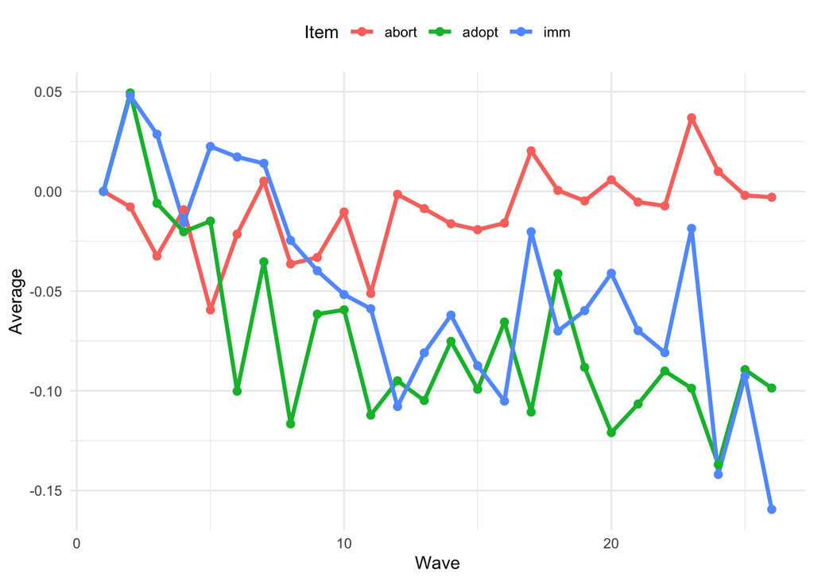

```r
# we plot avg score per item

library(tidyr)
library(ggplot2)
library(dplyr)
item_means <- data %>%
  select(wave, all_of(item_vars)) %>%
  pivot_longer(cols = all_of(item_vars),
    names_to = "item",
    values_to = "value"
  ) %>%
  group_by(item, wave) %>%
  summarise(mean_value = mean(value, na.rm = TRUE),
    n = sum(!is.na(value)),
    .groups = "drop"
  )

ggplot(item_means,
       aes(x = wave, y = mean_value, color = item)) +
  geom_line(linewidth = 1.2) +
  geom_point(size = 2) +
  labs(
    x = "Wave", y = "Average", color = "Item") +
  theme_minimal() +
  theme(legend.position = "top"
  )
```

```r
# when looking at the plot we must remember the responses are mean centered.
```

in the plot we can see that imm has a clearer downward trend in the responses, so we choose this item going forward. (We could also choose adopt, since they have similar trends, this is a bit arbitrary) Now we have to choose a participant for the 1 item 1 person ARMA model